# Parenting Books on Amazon.sg

Web-scrapping titles

www.gerardchung.com

2022-05-02

## What kinds of Parenting books sold on Amazon.sg?

I was curious to know the kinds of parenting books sold on Amazon.sg. Searching “parenting” in Amazon.sg gets a list of books such as [this](https://www.amazon.sg/s?k=parenting&i=stripbooks&rh=p_36%3A100-&s=relevancerank&page=2&crid=3DGF4OTW5NWUS&qid=1650974729&rnid=6469114051&sprefix=parenting%2Cstripbooks%2C219&ref=sr_pg_2)

[figure not shown]

## Web-scrapping search results off Amazon.sg website

Let’s take a look at the variables in the dataframe.

```r
glimpse(data_all)
```

```
## Rows: 1,198
## Columns: 3
## $ id       <int> 1, 2, 3, 4, 5, 6, 7, 8, 9, 10, 11, 12, 13, 14, 15, 16, 17, 18…
## $ title    <chr> "Family Fun Night Conversation Starters Placemats: 375 Questi…
## $ pub_type <chr> "Novelty Book", "Paperback", "Hardcover", "Paperback", "Hardc…
```

From first few rows of the data, we can see the titles and type of publication. The book **“How to Raise Kids Who Aren’t Assholes”** seems interesting.

```r
library(knitr)
data_all %>%  head(5) %>% kable(digits = 2)
```

| id | title | pub_type |
| --- | --- | --- |
| 1 | Family Fun Night Conversation Starters Placemats: 375 Questions That Celebrate Family and Create Lasting Memories | Novelty Book |
| 2 | Cribsheet: A Data-Driven Guide to Better, More Relaxed Parenting, from Birth to Preschool: 2 | Paperback |
| 3 | Parenting: 14 Gospel Principles That Can Radically Change Your Family | Hardcover |
| 4 | The Danish Way of Parenting: What the Happiest People in the World Know About Raising Confident, Capable Kids | Paperback |
| 5 | How to Raise Kids Who Aren’t Assholes: Science-Based Strategies for Better Parenting–from Tots to Teens | Hardcover |

## Preprocessing the data

Let’s turn the dataframe into a corpus. Then using Quanteda’s package to tokenize the titles and also perform some pre-processing steps. I removed any numbers, punctuations, filtered out stopwords (which are not useful for analysis, e.g., is, and, we). And then convert the tokens object to dfm.

```r
corp <- corpus(data_all,
               docid_field = "id",
               text_field = "title")

tok <-
    corp %>%
    tokens(remove_numbers = T,
           remove_punct = T,
           remove_separators = T,
           remove_symbols = T,
           remove_url = T,
           include_docvars = T) %>%
    tokens_tolower() %>%
    tokens_select(pattern = c(stopwords("en")),
                  selection = "remove") %>%
    tokens_ngrams(n = 1:2)

dfm <-
    tok %>% dfm()
```

## Popular words used in the titles

```r
library(quanteda.textstats)
topfeatures(dfm, n = 20,scheme = "docfreq")
```

```
##     guide      kids parenting  children     child      baby      book   parents
##       180       149       135       130       129        80        80        77
##   raising   edition      life      help       new      love    family     birth
##        72        68        67        65        51        50        49        44
## pregnancy     happy   child's   healthy
##        41        40        38        37
```

Let’s try to plot the number of occurrences of words in the titles. Let’s convert the dfm to a tidy format where it is a table with one-token-per-document-per-row

Each word in each document is given a row in a tidy format.

| document | term | count |
| --- | --- | --- |
| 1 | family | 2 |
| 1 | fun | 1 |
| 1 | night | 1 |
| 1 | conversation | 1 |
| 1 | starters | 1 |
| 1 | placemats | 1 |
| 1 | questions | 1 |
| 1 | celebrate | 1 |
| 1 | create | 1 |
| 1 | lasting | 1 |
| 1 | memories | 1 |
| 1 | family_fun | 1 |
| 1 | fun_night | 1 |
| 1 | night_conversation | 1 |
| 1 | conversation_starters | 1 |
| 1 | starters_placemats | 1 |
| 1 | placemats_questions | 1 |
| 1 | questions_celebrate | 1 |
| 1 | celebrate_family | 1 |
| 1 | family_create | 1 |

## Plotting frequency of word occurrences in book titles

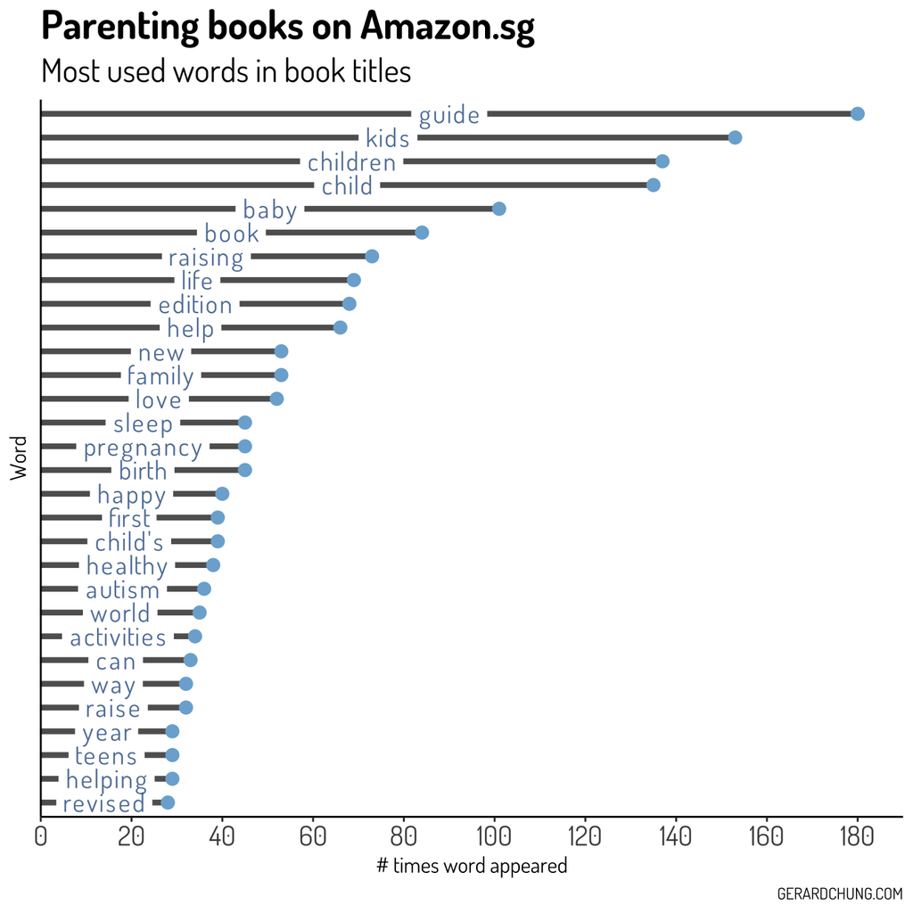

```r
word_freq <-
    data_tidy %>%
    group_by(term) %>%
    summarize(word_n = sum(count)) %>%
    ungroup()

word_freq %>%
    filter(term != "parent" & term != "parents" & term != "parenting") %>%
    slice_max(word_n, n = 30) %>%
    ggplot(aes(x = word_n, y = reorder(term,word_n))) +
    geom_textsegment(aes(yend=term, xend=-0, label = term),
                 alpha = .7,
                 size = 5,
                 linewidth = 1.5,
                 linecolor = "black",
                 textcolor = nus_blue, fontface = 7, family = font
              ) +
        geom_point(size = 3, color = tar_blue,  alpha = 1) +
    labs(title = "Parenting books on Amazon.sg",
         subtitle = "Most used words in book titles",
         x = "# times word appeared",
         y = "Word",
         caption = "GERARDCHUNG.COM"
    ) +
    theme(#legend.position = "none",
        plot.title = element_text(size=22, face="bold"),
        plot.subtitle = element_text(size=18),
        axis.title.x = element_text(size = 12),
        axis.title.y = element_text(size = 12),
        axis.text.y = element_blank(),
       # axis.text.y = element_text(size=12),
        axis.text.x = element_text(size=15),
       axis.ticks.y = element_blank()
    ) +
    scale_x_continuous(limits = c(0, 190), breaks = seq(0, 200, by = 20), expand = c(0, 0))
```

We have books that are **guides** to parenting. Books for children ranging from **infants, toddlers, children, and teens**. Books probably for **new parents**. Book for **pregnant** parents. Books to improve **sleep** for the newborns. Some books are **revised** books and some spawned **new editions**. Activity books.

## More books for mothers?

Would there be more book titles mentioning “mothers” than “fathers”?

```r
str_view_all(dadmum1$title, regex(pattern = "dad|mum|mother|father|dads|mums|mothers|fathers", ignore_case = T), match =T)
```

[interactive chart not shown]

There are **twice** the number of books offered for mothers than for fathers. Still, most books were written for parents in general and do not have references to either mothers or fathers.

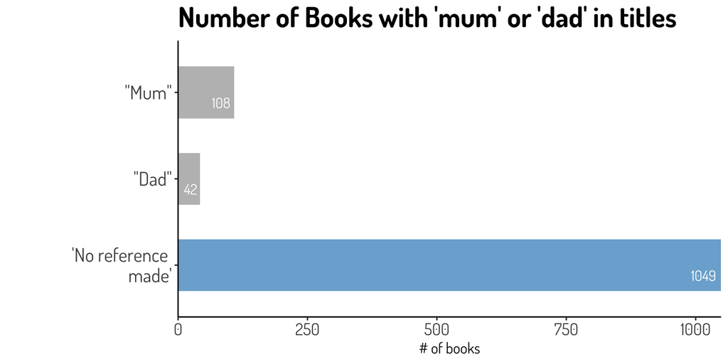

Would **word usage** in titles be different across books for mums and for dads?

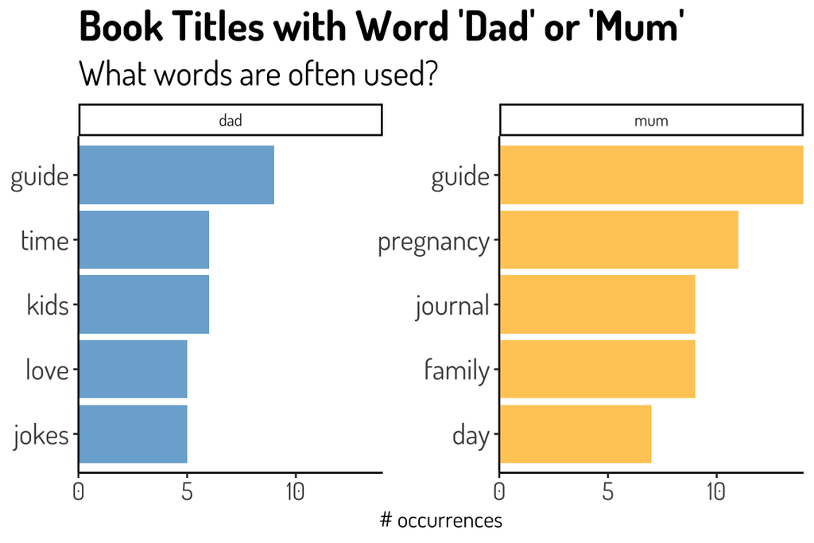

## What Topics Were These Parenting Books On Amazon.sg About?

To identify topics, I ran [structural topic modeling](https://www.structuraltopicmodel.com/) on the titles. STM is based on the Latent Dirichlet Allocation algorithm and its basic premise is to model documents as distributions of topics (topic prevalence) and topics as a distribution of words. Basically, it is used to quantitatively look at what latent topics generated these words used in the titles. STM provides a quick method to “qualitatively” analyze a large set of textual data. If you want to read more on analyzing open-ended survey responses using STM, read my paper [here](https://osf.io/enzst/)

### Identify the possible number of topics using exclusivity and semantic coherence

The first challenge is to identify the possible number of latent topics (k) that had generated the distribution of words and topics. Using a plot of semantic coherence and exclusivity, the best k number seems to be k=26 topics (it has the best semantic coherence and exclusivity)

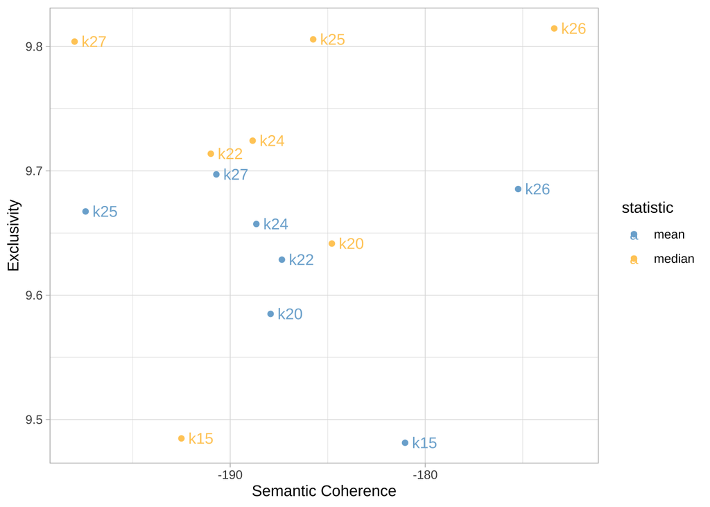

### Twenty-six Topics and their highly associated words

With a model of 26 topics best fitting the data, let’s take a look at the highly associated words for each of the 26 topics. We see books on guiding parents to love their kids/teens (Topic 1), on motherhood and pregnancy (Topic 3 and 24), helping parents to develop rich relationships with kids (Topic 25), babies and language development/sleeping (Topic 9 and 6), journaling the process of motherhood/pregnancy (Topic 11), and books on what to expect in the 1st year of parenting (Topic 5). There are also activity books for kids (Topic 14). Dad-Jokes books for parents (Topic 18). Books related to children with Autism (Topic 10). Books on home-schooling (Topic 13)

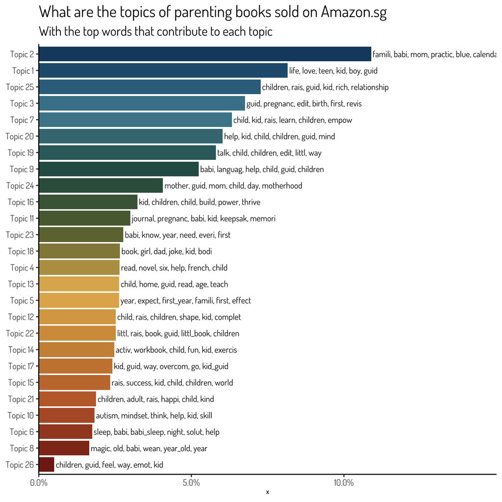

| Topic | Expected topic proportion | Top 6 terms |
| --- | --- | --- |
| Topic 2 | 0.109 | famili, babi, mom, practic, blue, calendar |
| Topic 1 | 0.082 | life, love, teen, kid, boy, guid |
| Topic 25 | 0.073 | children, rais, guid, kid, rich, relationship |
| Topic 3 | 0.068 | guid, pregnanc, edit, birth, first, revis |
| Topic 7 | 0.063 | child, kid, rais, learn, children, empow |
| Topic 20 | 0.060 | help, kid, child, children, guid, mind |
| Topic 19 | 0.058 | talk, child, children, edit, littl, way |
| Topic 9 | 0.052 | babi, languag, help, child, guid, children |
| Topic 24 | 0.041 | mother, guid, mom, child, day, motherhood |
| Topic 16 | 0.032 | kid, children, child, build, power, thrive |
| Topic 11 | 0.030 | journal, pregnanc, babi, kid, keepsak, memori |
| Topic 23 | 0.028 | babi, know, year, need, everi, first |
| Topic 18 | 0.027 | book, girl, dad, joke, kid, bodi |
| Topic 4 | 0.026 | read, novel, six, help, french, child |
| Topic 13 | 0.026 | child, home, guid, read, age, teach |
| Topic 5 | 0.026 | year, expect, first_year, famili, first, effect |
| Topic 12 | 0.025 | child, rais, children, shape, kid, complet |
| Topic 22 | 0.025 | littl, rais, book, guid, littl_book, children |
| Topic 14 | 0.025 | activ, workbook, child, fun, kid, exercis |
| Topic 17 | 0.024 | kid, guid, way, overcom, go, kid_guid |
| Topic 15 | 0.023 | rais, success, kid, child, children, world |
| Topic 21 | 0.019 | children, adult, rais, happi, child, kind |
| Topic 10 | 0.018 | autism, mindset, think, help, kid, skill |
| Topic 6 | 0.017 | sleep, babi, babi_sleep, night, solut, help |
| Topic 8 | 0.017 | magic, old, babi, wean, year_old, year |
| Topic 26 | 0.005 | children, guid, feel, way, emot, kid |

## Conclusion

It was interesting to see what topics of parenting books were offered on Amazon.sg. This ranges from practical books such as journaling books to joke books, to guides books, as well as books on skills and parenting knowledge. There are still more books for mums than for dads. What will be interesting to look at is how these topics of books change in line with their publication date. Would the number of books for dads change with time? Would certain topics (e.g., books on brain development) change with time?

## About me

Go to my personal website gerardchung.com to check out my other ongoing work